# Divide and Conquer Example from W3 schools

### Merge Sort

```python
def merge (arr1,arr2):
    i=0
    j=0
    # Array to store the merged sorted array
    result=[]
    while(i<len(arr1) and j<len(arr2)):
        #If arr1[i] is smaller than arr2[j], push arr1[i] into the result and move to the next element in arr1
        if arr2[j]>arr[i]:
            result.append(arr1[i])
            i+=1
        # If arr2[j] is smaller than arr1[i], push arr2[j] into the result and move to the next element in arr2
        else:
            result.append(arr2[j])
            j+=1

        # Push the remaining elements of arr1, if any
        while (i<len(arr1)):
            result.append(arr1[i])
            i+=1

            #Push the remaining elements of arr2, if any
        while(j<len(arr2)):
            result.append(arr2[j])
            j+=1

        return result
# Function to sort arr using merge sort
def mergeSort(arr):
    if len(arr)<=1:
        return arr
    mid=len(arr)//2
    # Sort the left half
    left=mergeSort(arr[:mid])
    # Sort the right half
    right=mergeSort(arr[mid:])

    return merge(left,right)

# Driver code

if __name__=='__main__':
    arr=[12,11,13,5,6,7]
    print("Given array is")
    print(*arr)
    arr=mergeSort(arr)
    print("\nSorted array is")
    print(*arr)
```

```
Given array is
12 11 13 5 6 7

Sorted array is
7 11 12 13 5 6
```

# Divide and conquer algorithm notes from Pt Berkeley Python Numerical Methods.

### Towers of Hanoi

The towers of hanoi problem consists of three vertical rods, or towers, and N disks of different sizes, each with a hole in the center so that the rod can slide through it.

The disks are originally stacked on one of the towers in order of descending size (i.e. the largest disc is on the bottom). The goal of the problem is to move all the disks to a different rod while complying with the following three rules:

1. Only one disk can be moved at a time.
2. Only the disk at the top of a stack may be moved.
3. A disk may not be placed on top of a smaller disk

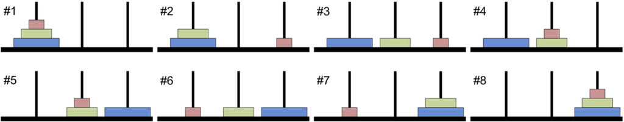

#### The essence of this problem

- The essence of this problem is to breakdown problems into smaller, easier-to-manage problems that can be referred to as **subproblems**.
- For this problem, it is relatively easy to see that moving a disk is easy but moving a stack of size N to several subproblems of moving a stack of size N-1.
- Consider a stack of N disks that we wish to move from tower 1 to tower 3, and let my_tower(N) move a stack of size N to the desired tower (i.e. display the moves).
- We need to move the top N-1 disks to the middle tower, then the bottom disk to the right tower and then the N-1 disks on the middle tower to the right tower.
- *my_tower* can display the instruction to move disk N, and then make recursive calls to my_tower(N-1) to handle moving the smaller towers.
- The calls to my_tower(N-1) make recursive calls to my_lower(N-2) and so on.
- A breakdown of three steps is depicted in the following figure.

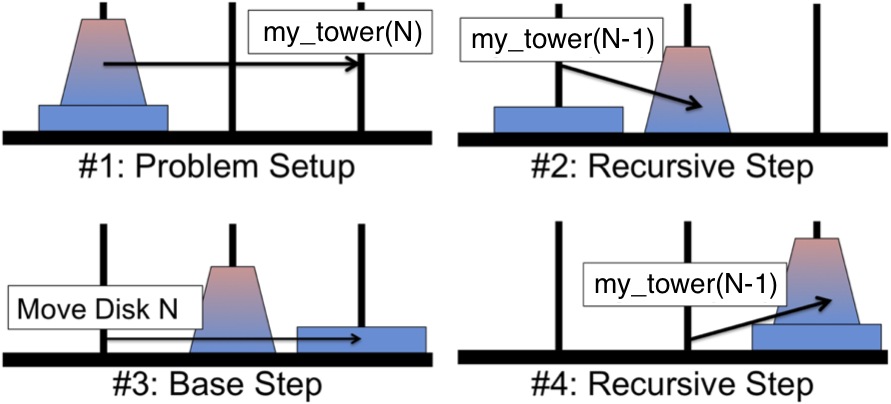

```python
def my_towers(N,from_tower, to_tower, alt_tower):
    if N!=0:
        #Recursive call that moves N-1 stack from starting tower
        # to alternative tower
        my_towers(N-1, from_tower, alt_tower, to_tower)

        #display to screen movement of bottom dosk from starting
        # tower to final tower
        print("Move disk %d from tower %d to tower %d."%(N, from_tower, to_tower))

        #recursive call that moves N-1 stack from alternate tower
        # to final tower
        my_towers(N-1, alt_tower, to_tower, from_tower)

my_towers(3,1,3,2)
```

```
Move disk 1 from tower 1 to tower 3.
Move disk 2 from tower 1 to tower 2.
Move disk 1 from tower 3 to tower 2.
Move disk 3 from tower 1 to tower 3.
Move disk 1 from tower 2 to tower 1.
Move disk 2 from tower 2 to tower 3.
Move disk 1 from tower 1 to tower 3.
```

### Quicksort

A list of numbers, A, is sorted if the elements are arranged in ascending or descending order. Although there are many ways of sorting a list, *quicksort* is a divide-and-conquer approach that is a very fast algorithm for sorting using a single processor.

The quicksort algorithm starts with the observation that sorting a list is hard, but comparison is easy. So, instead of sorting a list, we separate the list by comparing to a **pivot**.

Then a recursive call to quicksort is made on the two subproblems: the list of elements smaller than the pivot and the list of elements larger than the pivot.

Eventually the subproblems are small enough (i.e. list size of length 1 or 0) that sorting the list is trivial.

```python
def my_quicksort(lst):
    if len(lst)<=1:
        # list of length 1 is easiest to sort
        # because it is already sorted

        sorted_list=lst
    else:
        #select pivot as the first element of the list
        pivot=lst[0]

        #initialise lists for bigger and smaller elements
        #as well as those equal to the pivot
        bigger=[]
        smaller=[]
        same=[]

        # loop through list and put elements into appropriate arrays

        for item in lst:
            if item>pivot:
                bigger.append(item)
            elif item<pivot:
                smaller.append(item)
            else:
                same.append(item)
        sorted_list=my_quicksort(smaller) + same +my_quicksort(bigger)
    return sorted_list
my_quicksort([2,1,3,5,6,3,8,10])
```

```
[1, 2, 3, 3, 5, 6, 8, 10]
```